# AN588 Homework 03 (Fall 2023)

[figure not shown]

I scared myself after spending too much time looking at tv/movie zombies so here are Minecraft zombies instead

# Setting up

Set working directory

```r
setwd("~/Documents/GitHub/AN588_Zombies_svee")
```

Load packages

```r
library(curl)
library(tidyverse)
```

Load and preview dataset

```r
f <- curl("https://raw.githubusercontent.com/fuzzyatelin/fuzzyatelin.github.io/master/AN588_Fall23/zombies.csv")
zombie <- read.csv(f, header = TRUE)
head(zombie)
```

```
##   id first_name last_name gender   height   weight zombies_killed
## 1  1      Sarah    Little Female 62.88951 132.0872              2
## 2  2       Mark    Duncan   Male 67.80277 146.3753              5
## 3  3    Brandon     Perez   Male 72.12908 152.9370              1
## 4  4      Roger   Coleman   Male 66.78484 129.7418              5
## 5  5      Tammy    Powell Female 64.71832 132.4265              4
## 6  6    Anthony     Green   Male 71.24326 152.5246              1
##   years_of_education                           major      age
## 1                  1                medicine/nursing 17.64275
## 2                  3 criminal justice administration 22.58951
## 3                  1                       education 21.91276
## 4                  6                  energy studies 18.19058
## 5                  3                       logistics 21.10399
## 6                  4                  energy studies 21.48355
```

# Homework Questions

## Question 1

Calculate the population mean and standard deviation for each quantitative random variable (height, weight, age, number of zombies killed, and years of education). NOTE: You will not want to use the built in var() and sd() commands as these are for samples.

```r
# calculating population mean
m.height <- mean(zombie$height); m.height
```

```
## [1] 67.6301
```

```r
m.weight <- mean(zombie$weight); m.weight
```

```
## [1] 143.9075
```

```r
m.age <- mean(zombie$age); m.age
```

```
## [1] 20.04696
```

```r
m.killed <- mean(zombie$zombies_killed); m.killed
```

```
## [1] 2.992
```

```r
m.ed <- mean(zombie$years_of_education); m.ed
```

```
## [1] 2.996
```

Population SD is the square root of the population variance (sum of squares/N)

```r
# first i am making a function for my calculations
pop_sd <- function(x) {sqrt(sum((x - mean(x))^2)/(length(x)))}

# using the function to find population SD for each random variable
psd.height <- pop_sd(zombie$height); psd.height
```

```
## [1] 4.30797
```

```r
psd.weight <- pop_sd(zombie$weight); psd.weight
```

```
## [1] 18.39186
```

```r
psd.age <- pop_sd(zombie$age); psd.age
```

```
## [1] 2.963583
```

```r
psd.killed <- pop_sd(zombie$zombies_killed); psd.killed
```

```
## [1] 1.747551
```

```r
psd.ed <- pop_sd(zombie$years_of_education); psd.ed
```

```
## [1] 1.675704
```

## Question 2

Use {ggplot} to make boxplots of each of these variables by gender.

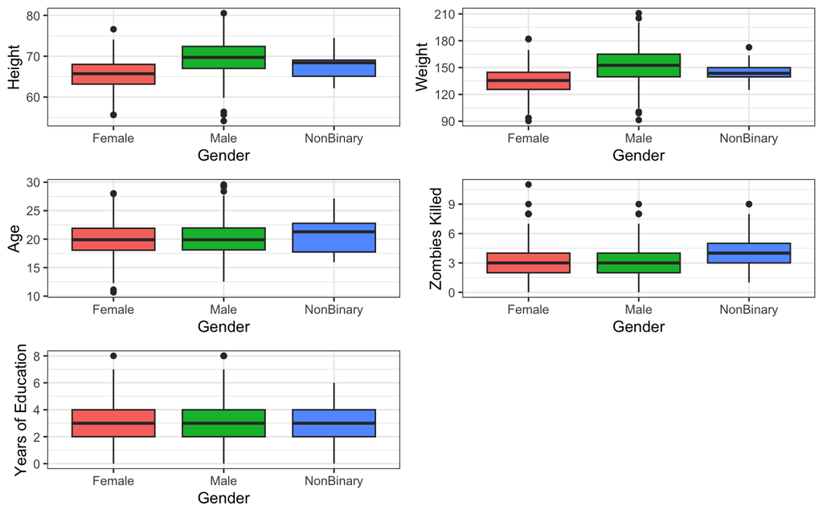

```r
# loading this package so i can arrange ggplot graphs, it works like par(mfrow)
library(egg)

# making boxplots for each variable and grouping by gender
plot_height <- ggplot(data = zombie, aes(x = gender, y = height, fill = gender)) + # calling dataset and axes
                geom_boxplot(na.rm = TRUE, show.legend = FALSE) + # removing NA values and legend
                xlab("Gender") + ylab("Height") + theme_bw() # labeling axes and adding bw theme

plot_weight <- ggplot(data = zombie, aes(x = gender, y = weight, fill = gender)) +
                geom_boxplot(na.rm = TRUE, show.legend = FALSE) +
                xlab("Gender") + ylab("Weight") + theme_bw()

plot_age <- ggplot(data = zombie, aes(x = gender, y = age, fill = gender)) +
                geom_boxplot(na.rm = TRUE, show.legend = FALSE) +
                xlab("Gender") + ylab("Age") + theme_bw()

plot_killed <- ggplot(data = zombie, aes(x = gender, y = zombies_killed, fill = gender)) +
                geom_boxplot(na.rm = TRUE, show.legend = FALSE) +
                xlab("Gender") + ylab("Zombies Killed") + theme_bw()

plot_edu <- ggplot(data = zombie, aes(x = gender, y = years_of_education, fill = gender)) +
                geom_boxplot(na.rm = TRUE, show.legend = FALSE) +
                xlab("Gender") + ylab("Years of Education") + theme_bw()

ggarrange(plot_height, plot_weight, plot_age, plot_killed, plot_edu, ncol=2, nrow=3)
```

## Question 3

Use {ggplot} to make scatterplots of height and weight in relation to age. Do these variables seem to be related? In what way?

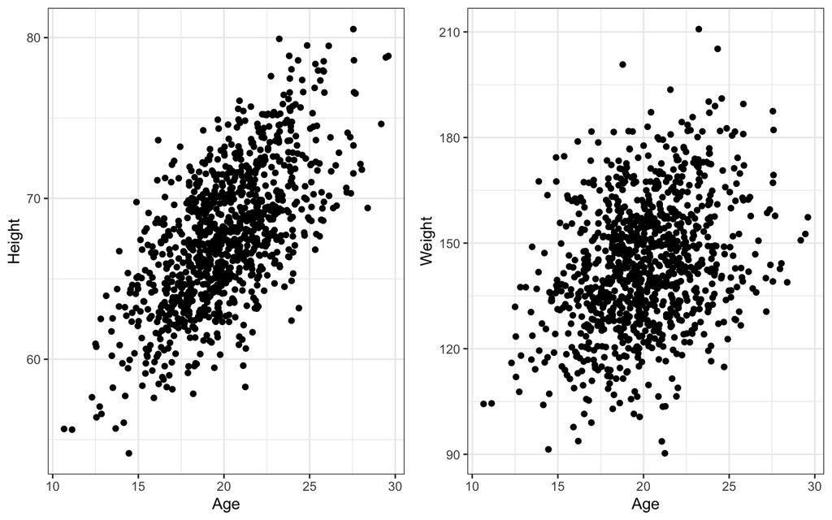

```r
# we use geom_point to make scatter plots with ggplot!
height_age <- ggplot(data = zombie, aes(x = age, y = height)) + geom_point() +
              xlab("Age") + ylab("Height") + theme_bw()

weight_age <- ggplot(data = zombie, aes(x = age, y = weight)) + geom_point() +
              xlab("Age") + ylab("Weight") + theme_bw()

ggarrange(height_age, weight_age, ncol = 2, nrow = 1)
```

These variables look related! It looks like height and weight both increase as age increases. However, there is greater spread for the points related to weight and age.

## Question 4

Using histograms and Q-Q plots, check whether the quantitative variables seem to be drawn from a normal distribution. Which seem to be and which do not (hint: not all are drawn from the normal distribution)? For those that are not normal, can you determine from which common distribution they are drawn?

I’m first making histograms for each quantitative variable (height, weight, age, number zombies killed, and years of education)

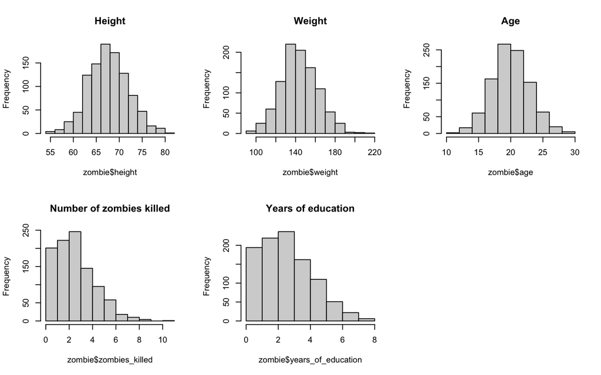

```r
par(mfrow = c(2, 3))
hist(zombie$height, main = "Height")
hist(zombie$weight, main = "Weight")
hist(zombie$age, main = "Age")
hist(zombie$zombies_killed, main = "Number of zombies killed")
hist(zombie$years_of_education, main = "Years of education")
```

Next, I’m assessing the same data using QQ plots

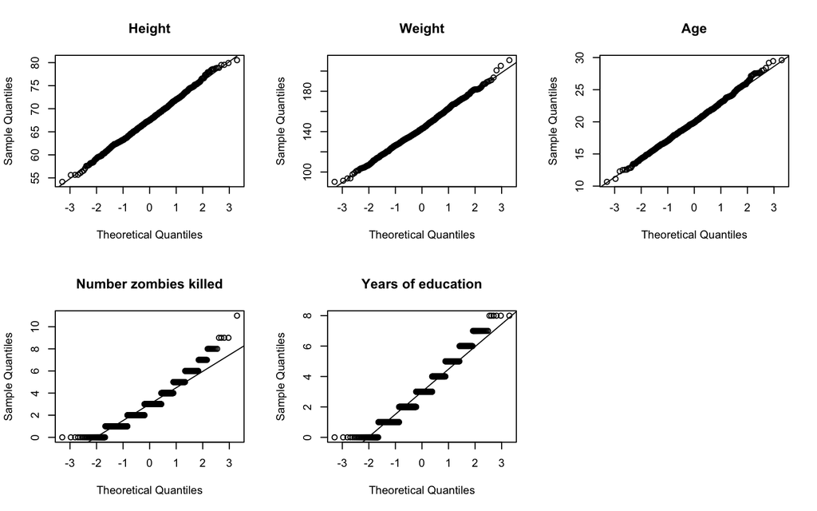

```r
par(mfrow = c(2, 3))
qqnorm(zombie$height, main = "Height"); qqline(zombie$height)
qqnorm(zombie$weight, main = "Weight"); qqline(zombie$weight)
qqnorm(zombie$age, main = "Age"); qqline(zombie$age)
qqnorm(zombie$zombies_killed, main = "Number zombies killed"); qqline(zombie$zombies_killed)
qqnorm(zombie$years_of_education, main = "Years of education"); qqline(zombie$years_of_education)
```

Height, weight, and age look normally distributed according to these qqplots. The second row with number of zombies killed and years of education don’t look normally distributed. The step ladder shape comes from the fact that data from these variables are discrete and rounded, but the points do not fall along x=y. This looks like a Poisson distribution.

## Question 5

Now use the sample() function to sample ONE subset of 30 zombie survivors (without replacement) from this population and calculate the mean and sample standard deviation for each variable. Also estimate the standard error for each variable, and construct the 95% confidence interval for each mean. Note that for the variables that are not drawn from the normal distribution, you may need to base your estimate of the CIs on slightly different code than for the normal…

[This link](https://www.statmethods.net/management/subset.html) helped me subset my data:

```r
# taking my random sample of size 30 without replacement from original dataset
set.seed(123)
zombie_subset <- zombie[sample(1:nrow(zombie), 30, replace=FALSE),]
head(zombie_subset)
```

```
##      id first_name last_name    gender   height   weight zombies_killed
## 415 415     Bonnie    Jordan    Female 63.58240 141.4377              2
## 463 463   Clarence     Burns      Male 74.83504 157.0047              2
## 179 179      Marta  Castillo NonBinary 68.29124 140.6936              3
## 526 526      Steve     Ortiz      Male 70.03853 148.9649              2
## 195 195   Jonathan   Ramirez NonBinary 68.74930 147.6104              2
## 938 938  Katherine    Burton    Female 64.01953 123.3189              1
##     years_of_education                 major      age
## 415                  3        energy studies 15.33620
## 463                  4            philosophy 21.22975
## 179                  1     military strategy 19.18691
## 526                  3 environmental science 24.70151
## 195                  5          pharmacology 16.50640
## 938                  4         city planning 18.66627
```

**Calculating sample mean, sample standard deviation, standard error of the mean, and 95% confidence interval for each mean for the same variables again, starting with HEIGHT:**

```r
# calculating mean
mean_height <- mean(zombie_subset$height); mean_height
```

```
## [1] 67.63939
```

```r
# calculating SD, we can use the built-in function this time because we're drawing from a sample!
sd_height <- sd(zombie_subset$height); mean_height
```

```
## [1] 67.63939
```

```r
# calculating standard error of the mean using the equation: sd/sqrt(n)
sem_height <- sd_height/sqrt(length(zombie_subset$height)); sem_height
```

```
## [1] 0.6445838
```

```r
# calculating 95% CIs with help from Module 9
lower_h <- mean_height - qnorm(1 - 0.05/2) * sem_height  # (1-alpha)/2 each in upper and lower tails of distribution
upper_h <- mean_height + qnorm(1 - 0.05/2) * sem_height
ci_height <- c(lower_h, upper_h); ci_height
```

```
## [1] 66.37603 68.90275
```

**Doing the same for WEIGHT:**

```r
mean_weight <- mean(zombie_subset$weight); mean_weight
```

```
## [1] 146.4101
```

```r
sd_weight <- sd(zombie_subset$weight); sd_weight
```

```
## [1] 14.64095
```

```r
sem_weight <- sd_weight/sqrt(length(zombie_subset$weight)); sem_weight
```

```
## [1] 2.673059
```

```r
lower_w <- mean_weight - qnorm(1 - 0.05/2) * sem_weight  # (1-alpha)/2 each in upper and lower tails of distribution
upper_w <- mean_weight + qnorm(1 - 0.05/2) * sem_weight
ci_weight <- c(lower_w, upper_w); ci_weight
```

```
## [1] 141.1710 151.6492
```

**Doing the same for AGE:**

```r
mean_age <- mean(zombie_subset$age); mean_age
```

```
## [1] 19.32927
```

```r
sd_age <- sd(zombie_subset$age); sd_age
```

```
## [1] 2.555914
```

```r
sem_age <- sd_age/sqrt(length(zombie_subset$age)); sem_age
```

```
## [1] 0.466644
```

```r
lower_a <- mean_age - qnorm(1 - 0.05/2) * sem_age  # (1-alpha)/2 each in upper and lower tails of distribution
upper_a <- mean_age + qnorm(1 - 0.05/2) * sem_age
ci_age <- c(lower_a, upper_a); ci_age
```

```
## [1] 18.41466 20.24387
```

**Doing the same for NUMBER OF ZOMBIES KILLED:**

```r
mean_killed <- mean(zombie_subset$zombies_killed); mean_killed
```

```
## [1] 2.533333
```

```r
sd_killed <- sd(zombie_subset$zombies_killed); sd_killed
```

```
## [1] 1.696514
```

```r
sem_killed <- sd_killed/sqrt(length(zombie_subset$zombies_killed)); sem_killed
```

```
## [1] 0.3097397
```

```r
# calculating upper and lower CIs - not sure if this is correct!!
poisson.test(length(zombie_subset$zombies_killed), conf.level = 0.95)
```

```
##
##  Exact Poisson test
##
## data:  length(zombie_subset$zombies_killed) time base: 1
## number of events = 30, time base = 1, p-value < 2.2e-16
## alternative hypothesis: true event rate is not equal to 1
## 95 percent confidence interval:
##  20.24087 42.82687
## sample estimates:
## event rate
##         30
```

**Doing the same for YEARS OF EDUCATION:**

```r
mean_edu <- mean(zombie_subset$years_of_education); mean_edu
```

```
## [1] 3.1
```

```r
sd_edu <- sd(zombie_subset$years_of_education); sd_edu
```

```
## [1] 1.422722
```

```r
sem_edu <- sd_edu/sqrt(length(zombie_subset$years_of_education)); sem_edu
```

```
## [1] 0.2597523
```

```r
# using same function as above - again, not sure if this is correct!
poisson.test(length(zombie_subset$years_of_education), conf.level = 0.95)
```

```
##
##  Exact Poisson test
##
## data:  length(zombie_subset$years_of_education) time base: 1
## number of events = 30, time base = 1, p-value < 2.2e-16
## alternative hypothesis: true event rate is not equal to 1
## 95 percent confidence interval:
##  20.24087 42.82687
## sample estimates:
## event rate
##         30
```

## Question 6

Now draw 99 more random samples of 30 zombie apocalypse survivors, and calculate the mean for each variable for each of these samples. Together with the first sample you drew, you now have a set of 100 means for each variable (each based on 30 observations), which constitutes a sampling distribution for each variable. What are the means and standard deviations of this distribution of means for each variable? How do the standard deviations of means compare to the standard errors estimated in [5]? What do these sampling distributions look like (a graph might help here)? Are they normally distributed? What about for those variables that you concluded were not originally drawn from a normal distribution?

```r
set.seed(123)

# making a dummy variable to hold each sample (?)
s <- NULL

# for loop to draw 99 random samples of 30 survivors
for (i in 1:100){
  s[[i]] <- zombie[sample(1:nrow(zombie), 30, replace=FALSE),]
  # how to calculate mean for each variable?
}

# now calculating mean for each variable for each sample
m <- NULL
for (i in 1:100){
  m[[i]] <- mean(s[[i]])
}
# this isn't working, i get a ridiculously long and aggressive error message
```

**I didn’t have enough time to try to make this for loop work so I’m sampling and calculating means for each variable another way**

```r
sample_height <- replicate(100, mean(sample(zombie$height, size = 30, replace = FALSE)))
sample_weight <- replicate(100, mean(sample(zombie$weight, size = 30, replace = FALSE)))
sample_age <- replicate(100, mean(sample(zombie$age, size = 30, replace = FALSE)))
sample_kills <- replicate(100, mean(sample(zombie$zombies_killed, size = 30, replace = FALSE)))
sample_edu <- replicate(100, mean(sample(zombie$years_of_education, size = 30, replace = FALSE)))
```

**Next, I’m calculating the mean for each variable**

```r
# calculating means
mean(sample_height)
```

```
## [1] 67.58277
```

```r
mean(sample_weight)
```

```
## [1] 143.2881
```

```r
mean(sample_age)
```

```
## [1] 19.96866
```

```r
mean(sample_kills)
```

```
## [1] 2.997667
```

```r
mean(sample_edu)
```

```
## [1] 3.023
```

**And calculating standard deviations**

```r
# calculating SDs
sd(sample_height)
```

```
## [1] 0.8263566
```

```r
sd(sample_weight)
```

```
## [1] 3.68373
```

```r
sd(sample_age)
```

```
## [1] 0.5742688
```

```r
sd(sample_kills)
```

```
## [1] 0.341294
```

```r
sd(sample_edu)
```

```
## [1] 0.3153284
```

The means are pretty much the same (give or take a few decimals) but the standard deviations are much smaller!

**To see what the sampling distributions look like, I’m creating histograms for each variable**

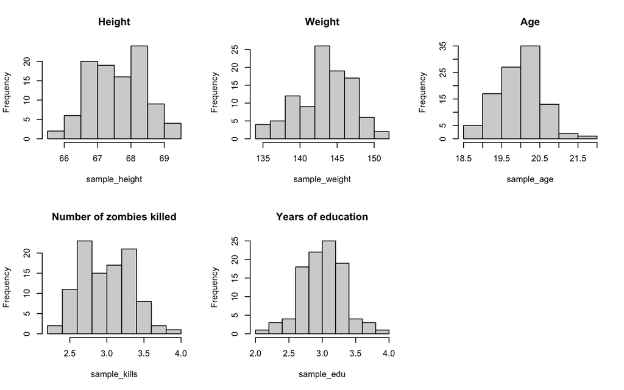

```r
par(mfrow = c(2, 3))
hist(sample_height, main = "Height")
hist(sample_weight, main = "Weight")
hist(sample_age, main = "Age")
hist(sample_kills, main = "Number of zombies killed")
hist(sample_edu, main = "Years of education")
```

**Also creating QQ plots for each variable**

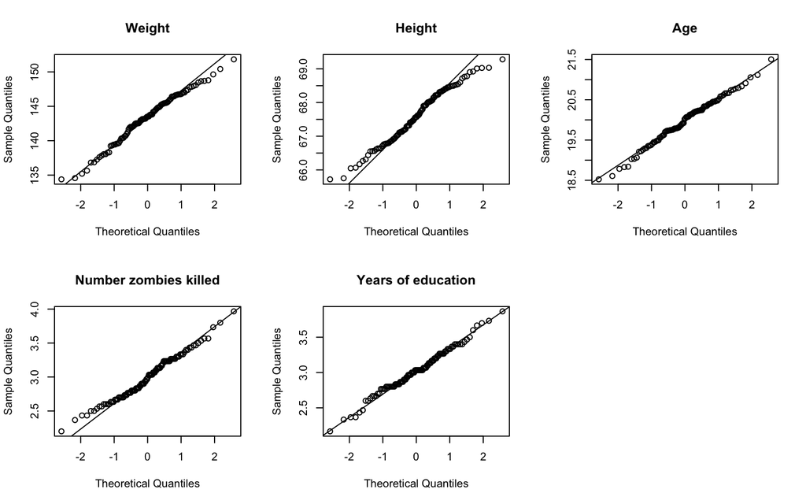

```r
par(mfrow = c(2, 3))
qqnorm(sample_weight, main = "Weight"); qqline(sample_weight)
qqnorm(sample_height, main = "Height"); qqline(sample_height)
qqnorm(sample_age, main = "Age"); qqline(sample_age)
qqnorm(sample_kills, main = "Number zombies killed"); qqline(sample_kills)
qqnorm(sample_edu, main = "Years of education"); qqline(sample_edu)
```

Height, weight, and age look less normally distributed than before. Number of zombies killed and years of education look somewhat more normally distributed (less skewed to one side) but still not really.

# Challenges Faced

1. I was initially unable to use curl to load my dataset. I kept receiving an error message until I realized that I pasted the wrong link. I needed to paste the link to the raw data, not the link to github’s preview of the .csv file.
2. Took me a while to look for equation for population SD, had to understand how it was different (mathematically) from sample SD and figure out how to turn it into a function that could be used for each variable
3. Some of the qqplots for question 4 looked like stepladders instead of a straight line, which confused me. I found out that this pattern comes from using discrete, rounded values. This checks out when looking at the data for numbers of zombies killed and years of education. I can still interpret the qqplot despite this different look.
4. I wasn’t sure how to calculate the confidence intervals for the Poisson distributed variables (numbers of zombies killed and years of education). I did some googling and found this [link](https://stats.stackexchange.com/questions/10926/how-to-calculate-confidence-interval-for-count-data-in-r). I’m not sure if this is correct and would like to revisit this in class and see it done ‘by hand’.
5. I couldn’t figure out how to make a for loop to start off queston 6! I was able to create 100 random samples but I didn’t know how to calculate the mean for each variable within the for loop. I didn’t have enough time to figure this out so I used a different method.